# Final Project

Ernest Jum

11/24/2016

# Executive Summary

In this project, we shall use the mtcars data set to address the following two questions:

1. Is an automatic or manual transmission better for MPG?
2. Quantify the MPG difference between automatic and manual transmissions.

Our analysis focuses on inference with a simple linear regression model and a multiple regression model. We shall observe that both models will support the conclusion that the cars in this study with manual transmissions have on average significantly higher MPG’s than cars with automatic transmissions.

## Data Processing

Here we load the mtcars data set and then transform categorical variables to factors using the factor function.

```r
mydata<-mtcars

mydata$cyl <- factor(mydata$cyl)
mydata$vs <- factor(mydata$vs)
mydata$gear <- factor(mydata$gear)
mydata$carb <- factor(mydata$carb)
mydata$am <- factor(mydata$am,labels=c('Automatic','Manual'))
```

## Exploratory Data Analysis

Here, we examine the relationships between different variables in the mtcars data set using the plots presented in Appendix 1.

One observes that the seven variables (cyl, disp, hp, drat, wt, vs, and am) are correlated with MPG.This relationship cannot be fully quantified unless we use linear models or we examine each one at a time.

We also observed from the box and density plots in Appendix 2 that MPG is higher when the car transmission is manual. The box and density plots gives an indicaton that the effects of transmission on MPG but we need to use the regression analysis to quantify and verify this conclusion.

```r
str(mydata)
```

[output not shown]

```r
summary(mydata)
```

```
##       mpg        cyl         disp             hp             drat
##  Min.   :10.40   4:11   Min.   : 71.1   Min.   : 52.0   Min.   :2.760
##  1st Qu.:15.43   6: 7   1st Qu.:120.8   1st Qu.: 96.5   1st Qu.:3.080
##  Median :19.20   8:14   Median :196.3   Median :123.0   Median :3.695
##  Mean   :20.09          Mean   :230.7   Mean   :146.7   Mean   :3.597
##  3rd Qu.:22.80          3rd Qu.:326.0   3rd Qu.:180.0   3rd Qu.:3.920
##  Max.   :33.90          Max.   :472.0   Max.   :335.0   Max.   :4.930
##        wt             qsec       vs             am     gear   carb
##  Min.   :1.513   Min.   :14.50   0:18   Automatic:19   3:15   1: 7
##  1st Qu.:2.581   1st Qu.:16.89   1:14   Manual   :13   4:12   2:10
##  Median :3.325   Median :17.71                         5: 5   3: 3
##  Mean   :3.217   Mean   :17.85                                4:10
##  3rd Qu.:3.610   3rd Qu.:18.90                                6: 1
##  Max.   :5.424   Max.   :22.90                                8: 1
```

```r
cdat <- ddply(mydata, "am", summarise, mpg.mean=mean(mpg))

cdat
```

```
##          am mpg.mean
## 1 Automatic 17.14737
## 2    Manual 24.39231
```

## Inference

Here, we test wheter the two types of transmissions (automatic and manual) have equal means.This is accomplished via the t-test. The test shows that the distribution of MPG is significantly different for manual and authomatic transmission cars with a p-value of 0.001374.

```r
t.test(mydata[mydata$am == "Automatic",]$mpg, mydata[mydata$am == "Manual",]$mpg)
```

```
##
##  Welch Two Sample t-test
##
## data:  mydata[mydata$am == "Automatic", ]$mpg and mydata[mydata$am == "Manual", ]$mpg
## t = -3.7671, df = 18.332, p-value = 0.001374
## alternative hypothesis: true difference in means is not equal to 0
## 95 percent confidence interval:
##  -11.280194  -3.209684
## sample estimates:
## mean of x mean of y
##  17.14737  24.39231
```

# Model Building and Selection

In this section, we build different regression models using with different variables in the model and then find the best model fit. Next, I perform analysis of residuals.

In order to build our model, we commence by building a model with all the variables as the predictors of MPG. The final model (final_model) with significant predictors is obtained using AIC with a stepwise model selection. Thus, only variables that are significant in predicting MPG are included in the final model.

```r
starting_model <- lm(mpg ~ ., data = mtcars)
final_model <- step(starting_model, direction = "both")
```

Here is a summary of the simple linear regression invloving *MPG* and *am*. We shall note here that the mean MPG difference is 7.245 MPG; the average MPG for cars with automatic transmissions is 17.147 MPG, and the average MPG for cars with manual transmissions is 24.392 MPG.

```r
base_model <- lm(mpg ~ am, data = mtcars)
summary(base_model)
```

```
##
## Call:
## lm(formula = mpg ~ am, data = mtcars)
##
## Residuals:
##     Min      1Q  Median      3Q     Max
## -9.3923 -3.0923 -0.2974  3.2439  9.5077
##
## Coefficients:
##             Estimate Std. Error t value Pr(>|t|)
## (Intercept)   17.147      1.125  15.247 1.13e-15 ***
## am             7.245      1.764   4.106 0.000285 ***
## ---
## Signif. codes:  0 '***' 0.001 '**' 0.01 '*' 0.05 '.' 0.1 ' ' 1
##
## Residual standard error: 4.902 on 30 degrees of freedom
## Multiple R-squared:  0.3598, Adjusted R-squared:  0.3385
## F-statistic: 16.86 on 1 and 30 DF,  p-value: 0.000285
```

Below is the summary of the selected final model with the most signinficant paramters.

```r
summary(final_model)
```

```
##
## Call:
## lm(formula = mpg ~ wt + qsec + am, data = mtcars)
##
## Residuals:
##     Min      1Q  Median      3Q     Max
## -3.4811 -1.5555 -0.7257  1.4110  4.6610
##
## Coefficients:
##             Estimate Std. Error t value Pr(>|t|)
## (Intercept)   9.6178     6.9596   1.382 0.177915
## wt           -3.9165     0.7112  -5.507 6.95e-06 ***
## qsec          1.2259     0.2887   4.247 0.000216 ***
## am            2.9358     1.4109   2.081 0.046716 *
## ---
## Signif. codes:  0 '***' 0.001 '**' 0.01 '*' 0.05 '.' 0.1 ' ' 1
##
## Residual standard error: 2.459 on 28 degrees of freedom
## Multiple R-squared:  0.8497, Adjusted R-squared:  0.8336
## F-statistic: 52.75 on 3 and 28 DF,  p-value: 1.21e-11
```

Here, we compare this model with the model with only *am* as the independent variable.

```r
anova(base_model, final_model)
```

```
## Analysis of Variance Table
##
## Model 1: mpg ~ am
## Model 2: mpg ~ wt + qsec + am
##   Res.Df    RSS Df Sum of Sq      F   Pr(>F)
## 1     30 720.90
## 2     28 169.29  2    551.61 45.618 1.55e-09 ***
## ---
## Signif. codes:  0 '***' 0.001 '**' 0.01 '*' 0.05 '.' 0.1 ' ' 1
```

```r
final_model$anova
```

```
##     Step Df   Deviance Resid. Df Resid. Dev      AIC
## 1        NA         NA        21   147.4944 70.89774
## 2  - cyl  1 0.07987121        22   147.5743 68.91507
## 3   - vs  1 0.26852280        23   147.8428 66.97324
## 4 - carb  1 0.68546077        24   148.5283 65.12126
## 5 - gear  1 1.56497053        25   150.0933 63.45667
## 6 - drat  1 3.34455117        26   153.4378 62.16190
## 7 - disp  1 6.62865369        27   160.0665 61.51530
## 8   - hp  1 9.21946935        28   169.2859 61.30730
```

# Appendices

## Appendix 1: Correlations

1. Here we examine the relationship between the variables in this data set. It is difficult to inertprete results from using the pairs command in R. But still we present them here.

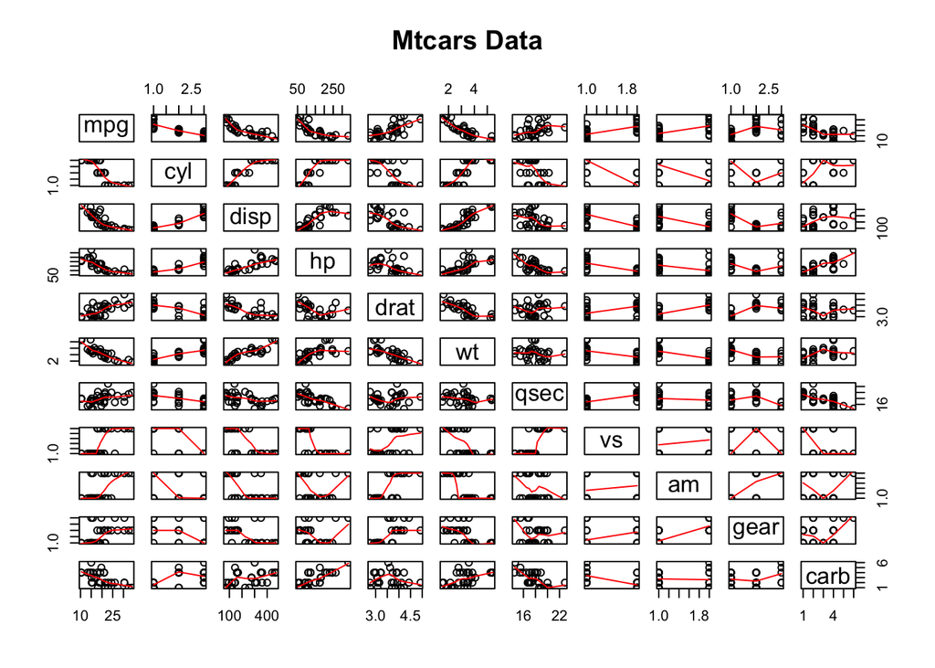

```r
pairs(mydata, panel = panel.smooth, main="Mtcars Data")
```

## Appendix 2: Box and Density Plot

[figure not shown]

```r
g<-ggplot(data=mydata, aes(x=am, y=mpg, fill=am))
g<-g+ geom_boxplot()
g<-g+ guides(fill=FALSE) + coord_flip()
g<-g+xlab("Miles Per Gallon (MPG)")
g<-g+ylab("Transmission Type")
g
```

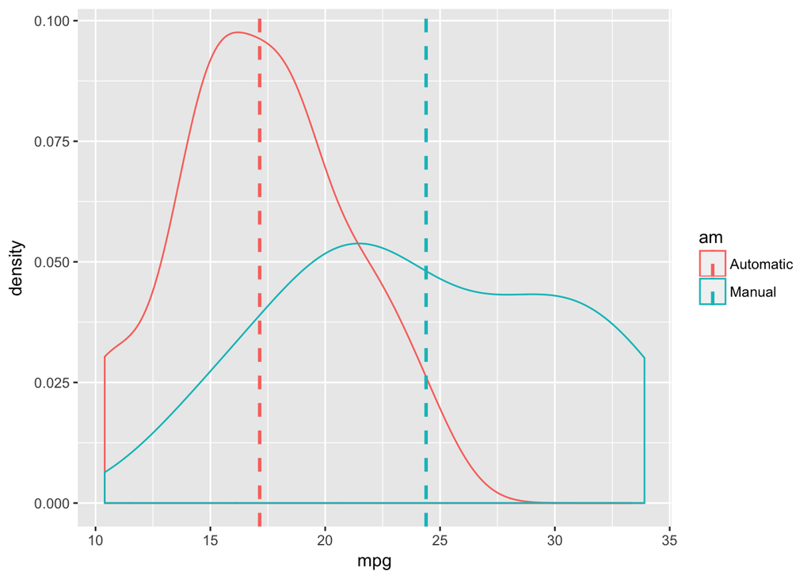

```r
# Density plots with means
g<-ggplot(data=mydata, aes(x=mpg, colour=am)) +geom_density()
g<-g+geom_vline(data=cdat, aes(xintercept=mpg.mean,  colour=am),
             linetype="dashed", size=1)
g
```

## Appendix 3: Model Dignostics

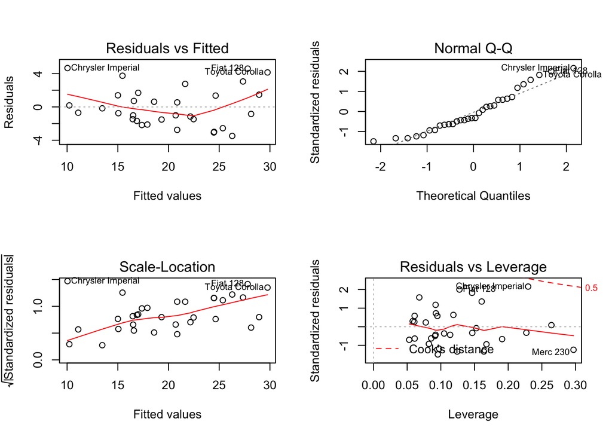

```r
par(mfrow=c(2, 2))
plot(final_model)
```

```r
outlier <- hatvalues(final_model)
tail(sort(outlier),3)
```

```
##   Chrysler Imperial Lincoln Continental            Merc 230
##           0.2296338           0.2642151           0.2970422
```

```r
influential <- dfbetas(final_model)
tail(sort(influential[,3]),3)
```

```
## Chrysler Imperial    Toyota Corolla          Fiat 128
##         0.3366781         0.4514928         0.4968861
```